# 🚘 💵 Lab 8: Used cars and cross-validation

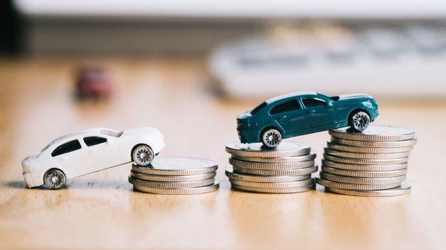

**Due Date**: Friday, November 8th at midnight.

**Note:** HW4 includes material covered in this lab. HW4 is due Monday 11/4. So, aim to finish this lab by Friday 11/1.

Labs are submitted via Gradescope.

- You will submit (1) a .Rmd file with your code, (2) a PDF of your code and output.
- To generate a PDF of your code and output, **do not knit to PDF**. Instead, knit your .Rmd file as HTML, open the HTML file in a web browser, and then **print the HTML as a PDF, making sure that none of your code or output is cut off.** You can generate an HTML file in RStudio by pressing `Knit` and then `Knit to HTML`.
- The knitting process will not work if there are errors in your code, so be sure to leave plenty of time to knit your lab notebooks before the deadline.

## ✅ Setup and data import

In this lab, we will explore underfitting, overfitting, and cross-validation with the same data from [Edmunds.com](https://edmunds.com) that we used in Lab 7.

- **Previous goal from Lab 7:** Predict the price of a used car using its features (e.g., color).
- **Goal of Lab 8:** Build a model that makes accurate predictions on data that was not used to train the model.

```r
# Load in additional functions
library(tidyverse)
```

```r
library(lubridate)

# Use three digits past the decimal point
# Don't use scientific notation
options(digits = 3, scipen=999)

# Format plots with a white background and dark features.
theme_set(theme_bw())

cars = read_tsv("https://jdgrossman.com/assets/used-cars.tsv") %>%
  # All cars in the dataset are of type "used"
  select(-type)
# peek at 10 random rows
sample_n(cars, 10)
```

| year | make | model | trim | mileage | price |
| --- | --- | --- | --- | --- | --- |
| 2011 | Infiniti | G Sedan | G37 Journey | 40670 | 22599 |
| 2013 | Honda | Civic | EX | 18517 | 17382 |
| 2012 | Infiniti | G Sedan | G25 Journey | 20353 | 23599 |
| 2010 | Honda | Civic | LX | 60467 | 12991 |
| 2013 | Volkswagen | Jetta | SE PZEV | 36706 | 13998 |
| 2009 | Lexus | RX 350 | Base | 78773 | 20489 |
| 2011 | Infiniti | G Sedan | G37 Journey | 32734 | 22995 |
| 2012 | Volkswagen | Jetta | TDI | 26360 | 18995 |
| 2007 | Cadillac | CTS | Base | 111867 | 9998 |
| 2011 | Acura | MDX | Base | 43010 | 29995 |

## 🚀 Exercise 1

Using the `sample` function, randomly divide the cars dataset into two pieces called `cars_training` and `cars_validation`.

- `cars_training` should contain approximately 80% of the dataset, while `cars_validation` should include 20% of the dataset.
- Make sure that there is no overlap between the two datasets.
- Note that there are many different ways to split the data. You can ask PingPong to show you some different ways!

```r
# Your code here!

# This code makes your random split the same every time you run the code.
set.seed(131)
```

## 🚀 Exercise 2

Fit a linear model to the `cars_training` dataset that predicts `price` based on `year`.

- Store your model as `model_w_year`.
- Print the summary of your model.
- What is the interpretation of the `year` coefficient?

```r
# Your code here!
```

## 🚀 Exercise 3

Using `mutate` and `as.character` to convert the `year` column in the `cars_training` to a string.

- Then, refit your model from Exercise 2, storing it as `model_w_str_year`.
- How does the $R^2$ of `model_w_str_year` compare to the $R^2$ of `model_w_year` in Exercise 2? Why?

```r
# Your code here!
```

## 🚀 Exercise 4

Compute the RMSE of `model_w_str_year` on the `cars_training` and `cars_validation` datasets.

- Recall that RMSE is the root mean squared error, where error is defined as the difference between the predicted price and the actual price.
- `predict(model, newdata = df)` will return the predicted outcomes for the data in dataframe `df`.
- Are there any differences in the two RMSE values? What is the reason for this difference?

```r
# Your code here!
```

## 🚀 Exercise 5

Fit a new model to `cars_training` that predicts `price` based on `year`, `make`, and `mileage`.

- Store your model as `model_w_year_make_mileage`.
- Calculate the RMSE on the training data and the validation data. What do you notice?
- Is there evidence of overfitting? Explain.

```r
# Your code here!
```

## ⚔️ K-fold cross validation

In the last two exercises, we will estimate the out-of-sample RMSE of the `model_w_year_make_mileage` specification using cross-validation.

Recall that K-fold cross-validation has the following steps:

1. Split the data into K-folds of approximately the same size.
2. Iterate from 1 to K. At each iteration, hold out one fold, and train the model on the remaining folds. Then, validate on the held-out fold.
3. Average the results over the K iterations.

## 🚀 Exercise 6

Split the `cars` data into 5 folds of approximately equal size.

- One way to do this: First, randomly shuffle the data. Then, label the rows with a fold number (e.g., 1, 2, 3, 4, 5, 1, 2, 3, 4, 5,…). You can use a new column for the fold number.
- `sample_frac(df, 1)` will randomly shuffle the rows of dataframe `df`.
- `rep(c(1,2,3), length.out = 8)` returns `c(1,2,3,1,2,3,1,2)`.

```r
# Your code here!
```

## 🚀 Exercise 7

Using a `for` loop, iterate from 1 to 5.

- At each iteration, hold out the fold with the corresponding fold number, and train the `model_w_year_make_mileage` specification on the remaining data.
- Keep track of each RMSE in an external vector called `rmses`.
- Finally, print the average of the RMSEs.
- How does this **CV RMSE** compare to the RMSE of the simple validation set above?
- **Note:** Remember to convert the `year` column to a character as we did above.

```r
# Your code here!
```